# Project

### Download Necessary Packages

```python
!pip install folium --upgrade
!pip install geopandas --upgrade
!pip install beautifulsoup4 --upgrade
!pip install plotly
!pip install plotly nbconvert
!pip install pandoc --upgrade
!pip install -U scikit-learn
```

[output not shown]

### Import Packages

```python
import pandas as pd
# Import any data cleaning libraries here

# Import your selected models here

# Import any other libraries here
import numpy as np
from zipfile import ZipFile
from io import BytesIO
import urllib.request as urllib2
import matplotlib.pyplot as plt
import seaborn as sns
%matplotlib inline
from sklearn.preprocessing import StandardScaler
from sklearn.model_selection import train_test_split
from sklearn.linear_model import Ridge, Lasso, LinearRegression
from sklearn.model_selection import KFold



from sklearn.feature_selection import RFE
from sklearn.feature_selection import VarianceThreshold
from sklearn.model_selection import train_test_split
from sklearn.linear_model import Ridge, Lasso, LinearRegression
from sklearn.model_selection import KFold
from sklearn.ensemble import ExtraTreesClassifier
from sklearn.feature_selection import SelectFromModel

from sklearn import preprocessing


from sklearn import metrics
```

# NY Arraignment Flight Risk Prediction

```python
np.random.seed(0)
```

### Objective: Analyze and predict the judge decisions of defendant flight risk at arraignment hearings in the state of New York using data science techniques.

## I. Load Dataset

Load your dataset. Consider which columns you need for the analysis.

```python
url = "https://www.nycourts.gov/legacypdfs/court-research/PretrialReleaseDataExtractWeb.zip"
table = pd.read_csv(url)
table
```

|  | Internal_Case_ID | Gender | Race | Ethnicity | Age_at_Crime | Age_at_Arrest | Court_Name | Court_ORI | County_Name | District | ... | prior_misd_cnt | pend_vfo | pend_nonvfo | pend_misd | supervision | rearrest | rearrest_date | rearrest_firearm | rearrest_date_firearm | arr_cycle_id |
| --- | --- | --- | --- | --- | --- | --- | --- | --- | --- | --- | --- | --- | --- | --- | --- | --- | --- | --- | --- | --- | --- |
| 0 | 0xD3CD95500429FE2CAA4000D839002775CF76D3DC5027... | Female | Black | Unknown | 29 | 29 | Nassau District Court | NY029013J | Nassau | District 10N | ... | 0.0 | 0.0 | 0.0 | 0.0 | 0.0 | No Arrest | NaN | 0.0 | NaN | 782787.0 |
| 1 | 0x06F8C6AEB7E0B80BE48F59421DF53042C55F4E1DE047... | Male | Black | Non Hispanic | 29 | 29 | Troy City Court | NY041021J | Rensselaer | District 3 | ... | 1.0 | 0.0 | 0.0 | 0.0 | 0.0 | No Arrest | NaN | 0.0 | NaN | 791790.0 |
| 2 | 0x7A4C2FF5CF183368E75FCAB46F5284AA82640CEB0694... | Female | White | Hispanic | 22 | 22 | Yonkers City Court | NY059051J | Westchester | District 9 | ... | 0.0 | 0.0 | 1.0 | 0.0 | 0.0 | No Arrest | NaN | 0.0 | NaN | 473217.0 |
| 3 | 0x7F4BD0EDD8FC879A2E1484EF169F1CCED0F26487A554... | Female | Unknown | Unknown | 33 | 33 | Jamestown City Court | NY006011J | Chautauqua | District 8 | ... | NaN | NaN | NaN | NaN | NaN | NaN | NaN | NaN | NaN | NaN |
| 4 | 0x9B6A6F7372B141F23EBBF60BDB429DE7787F797CD2CD... | Male | Black | Non Hispanic | 49 | 49 | Suffolk 1st District Court | NY051033J | Suffolk | District 10S | ... | 10.0 | 0.0 | 1.0 | 0.0 | 0.0 | No Arrest | NaN | 0.0 | NaN | 610021.0 |
| ... | ... | ... | ... | ... | ... | ... | ... | ... | ... | ... | ... | ... | ... | ... | ... | ... | ... | ... | ... | ... | ... |
| 582976 | 0x08849779531465D598B171ED7EC577133D17615968F1... | Male | Black | Non Hispanic | 17 | 0 | Erie County Court | NY014013J | Erie | District 8 | ... | 0.0 | 0.0 | 0.0 | 0.0 | 0.0 | No Arrest | NaN | 0.0 | NaN | 73537.0 |
| 582977 | 0x820F48E0EA4C9F5492E9FC60FD1F85B30DC0A33AB24D... | Male | Black | Non Hispanic | 16 | 0 | New York Supreme Criminal Court | NY030015J | New York | District 1 | ... | 0.0 | 0.0 | 0.0 | 0.0 | 0.0 | No Arrest | NaN | 0.0 | NaN | NaN |
| 582978 | 0x032654E3B3D95D5EC493FA290EF382EF9F7FF1718D75... | Male | Black | Non Hispanic | 17 | 0 | Kings Supreme Criminal Court | NY023015J | Kings | District 2 | ... | NaN | NaN | NaN | NaN | NaN | NaN | NaN | NaN | NaN | NaN |
| 582979 | 0xA3147CE75E9C5C58BFB39772199392377EA3DD623179... | Male | White | Non Hispanic | 16 | 0 | Jefferson County Court | NY022013J | Jefferson | District 5 | ... | 0.0 | 0.0 | 0.0 | 0.0 | 0.0 | No Arrest | NaN | 0.0 | NaN | 79865.0 |
| 582980 | 0x30AC5A9E6812BD023838439790630CE77E464D1AB063... | Male | Black | Non Hispanic | 15 | 0 | Kings Supreme Criminal Court | NY023015J | Kings | District 2 | ... | 0.0 | 1.0 | 0.0 | 0.0 | 0.0 | No Arrest | NaN | 0.0 | NaN | 80090.0 |

582981 rows × 111 columns

## II. Data Cleaning

### A.“Leakage” is a term used in machine learning for when a model makes decisions using information that it would not actually have, resulting in unnaturally high performance. This is similar to what occurs when two variables have perfect collinearity. What would leakage look like in the context of this problem and dataset?

In this problem set, the dataset we are using contains data that can be used to predict whether or not an arraignment can occur and also contains data that discusses the aftermath of the arraignment decision. As such, because the data contains information that would only be there after the arraignment decision was made, the leakage can occur by using those columns to predict whether or not the defendent should be remanded or not (kept in jail or let out before hearing). Furthermore, leakage would also looks like letting in columns or data with repetitive information in columns/rows.

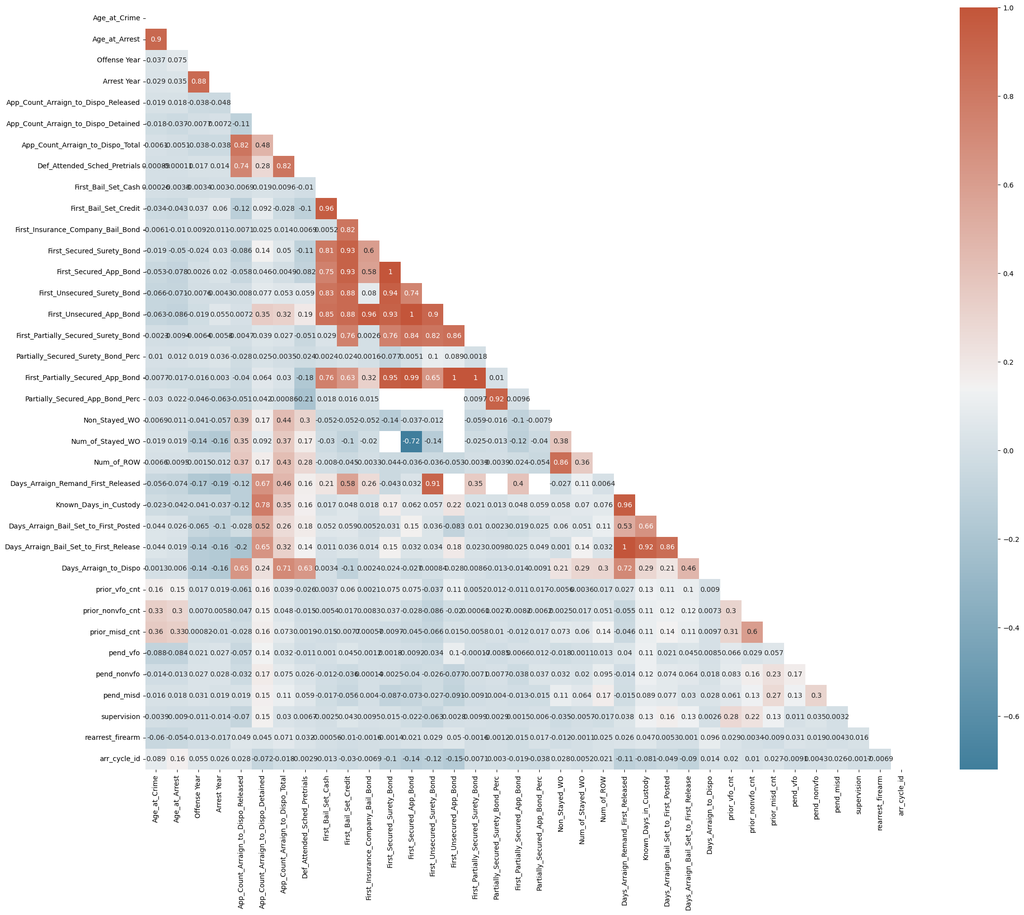

```python
corr = table.corr()
#
# Set up the matplotlib plot configuration
#
f, ax = plt.subplots(figsize=(25, 20))
#
# Generate a mask for upper traingle
#
mask = np.triu(np.ones_like(corr, dtype=bool))
#
# Configure a custom diverging colormap
#
cmap = sns.diverging_palette(230, 20, as_cmap=True)
#
# Draw the heatmap
#
sns.heatmap(corr, annot=True, mask = mask, cmap=cmap)
```

```python
table.describe()
```

|  | Age_at_Crime | Age_at_Arrest | Offense Year | Arrest Year | App_Count_Arraign_to_Dispo_Released | App_Count_Arraign_to_Dispo_Detained | App_Count_Arraign_to_Dispo_Total | Def_Attended_Sched_Pretrials | First_Bail_Set_Cash | First_Bail_Set_Credit | ... | Days_Arraign_to_Dispo | prior_vfo_cnt | prior_nonvfo_cnt | prior_misd_cnt | pend_vfo | pend_nonvfo | pend_misd | supervision | rearrest_firearm | arr_cycle_id |
| --- | --- | --- | --- | --- | --- | --- | --- | --- | --- | --- | --- | --- | --- | --- | --- | --- | --- | --- | --- | --- | --- |
| count | 582981.000000 | 582981.000000 | 580722.000000 | 566024.000000 | 582981.000000 | 582981.000000 | 582981.000000 | 366653.000000 | 8.043600e+04 | 7.931000e+03 | ... | 522391.000000 | 498553.000000 | 498553.000000 | 498553.000000 | 498553.000000 | 498553.000000 | 498553.000000 | 498553.000000 | 498553.000000 | 487440.000000 |
| mean | 34.382079 | 33.722368 | 2020.588991 | 2020.718001 | 3.435506 | 0.833871 | 4.269366 | 2.754283 | 2.580535e+04 | 2.066063e+04 | ... | 122.528560 | 0.215504 | 0.502119 | 1.978909 | 0.082068 | 0.169069 | 0.238611 | 0.082942 | 0.007933 | 623109.447161 |
| std | 12.281210 | 13.248955 | 1.287327 | 1.073839 | 3.653143 | 2.386434 | 4.144315 | 2.252032 | 5.380155e+05 | 5.653865e+04 | ... | 141.804801 | 0.501886 | 0.985159 | 3.103842 | 0.274468 | 0.374813 | 0.426235 | 0.275795 | 0.088713 | 175411.235317 |
| min | 0.000000 | 0.000000 | 1976.000000 | 1979.000000 | -2.000000 | 0.000000 | 0.000000 | 1.000000 | 1.000000e+00 | 0.000000e+00 | ... | 0.000000 | 0.000000 | 0.000000 | 0.000000 | 0.000000 | 0.000000 | 0.000000 | 0.000000 | 0.000000 | 4327.000000 |
| 25% | 25.000000 | 25.000000 | 2020.000000 | 2020.000000 | 1.000000 | 0.000000 | 2.000000 | 1.000000 | 1.000000e+02 | 2.500000e+03 | ... | 8.000000 | 0.000000 | 0.000000 | 0.000000 | 0.000000 | 0.000000 | 0.000000 | 0.000000 | 0.000000 | 524666.750000 |
| 50% | 32.000000 | 32.000000 | 2021.000000 | 2021.000000 | 2.000000 | 0.000000 | 3.000000 | 2.000000 | 5.000000e+03 | 7.000000e+03 | ... | 90.000000 | 0.000000 | 0.000000 | 0.000000 | 0.000000 | 0.000000 | 0.000000 | 0.000000 | 0.000000 | 638167.500000 |
| 75% | 42.000000 | 42.000000 | 2021.000000 | 2021.000000 | 4.000000 | 0.000000 | 5.000000 | 3.000000 | 2.000000e+04 | 2.000000e+04 | ... | 176.000000 | 0.000000 | 1.000000 | 3.000000 | 0.000000 | 0.000000 | 0.000000 | 0.000000 | 0.000000 | 754625.250000 |
| max | 99.000000 | 99.000000 | 2022.000000 | 2022.000000 | 140.000000 | 64.000000 | 142.000000 | 102.000000 | 1.500000e+08 | 2.500000e+06 | ... | 1010.000000 | 2.000000 | 4.000000 | 10.000000 | 1.000000 | 1.000000 | 1.000000 | 1.000000 | 1.000000 | 873150.000000 |

8 rows × 36 columns

```python
table.dtypes
```

```
Internal_Case_ID          object
Gender                    object
Race                      object
Ethnicity                 object
Age_at_Crime               int64
                          ...
rearrest                  object
rearrest_date             object
rearrest_firearm         float64
rearrest_date_firearm     object
arr_cycle_id             float64
Length: 111, dtype: object
```

### B. Drop the features that must be removed to prevent leakage. Describe the null values in the dataset and how you chose to deal with them. Clean the remaining data.

```python
drop_cols = ['Def_Attended_Sched_Pretrials', 'ROR_at_Arraign',
               'Bail_Set_and_Posted_at_Arraign', 'Bail_Set_and_Not_Posted_at_Arraign', 'NMR_at_Arraign',
               'Release Decision at Arraign', 'Representation_at_Securing_Order',
               'Pretrial_Supervision_at_Arraign','Contact_Pretrial_Service_Agency',
               'Electronic_Monitoring', 'Travel_Restrictions', 'Passport_Surrender',
               'No_Firearms_or_Weapons', 'Maintain_Employment', 'Maintain_Housing', 'Maintain_School',
               'Placement_in_Mandatory_Program', 'Removal_to_Hospital', 'Obey_Order_of_Protection',
               'Obey_Court_Conditions-Family_Offense', 'Other_NMR',


             'First_Bail_Set_Cash', 'First_Bail_Set_Credit', 'First_Insurance_Company_Bail_Bond',
               'First_Secured_Surety_Bond', 'First_Secured_App_Bond', 'First_Unsecured_Surety_Bond',
               'First_Unsecured_App_Bond', 'First_Partially_Secured_Surety_Bond',
               'Partially_Secured_Surety_Bond_Perc', 'First_Partially_Secured_App_Bond',
               'Partially_Secured_App_Bond_Perc', 'Bail_Made_Indicator',
               'Warrant_Ordered_btw_Arraign_and_Dispo', 'DAT_WO_WS_Prior_to_Arraign',
               'First_Bench_Warrant_Date', 'Non_Stayed_WO', 'Num_of_Stayed_WO',
               'Num_of_ROW','Disposition_Type', 'Disposition_Detail',
               'Dismissal_Reason', 'Disposition_Date',

             'Days_Arraign_Remand_First_Released', 'Known_Days_in_Custody',
               'Days_Arraign_Bail_Set_to_First_Posted', 'Days_Arraign_Bail_Set_to_First_Release',
               'Days_Arraign_to_Dispo', 'UCMSLiveDate',
             'rearrest', 'rearrest_date', 'rearrest_firearm', 'rearrest_date_firearm',
             'Top_Conviction_Law',
               'Top_Conviction_Article_Section', 'Top_Conviction_Attempt_Indicator',
               'Top_Charge_at_Conviction', 'Top_Charge_Severity_at_Conviction',
               'Top_Charge_Weight_at_Conviction', 'Top_Charge_at_Conviction_Violent_Felony_Ind',
            'Most_Severe_Sentence',"Top_Arraign_Attempt_Indicator","Order_of_Protection","Docket_Status"]
```

```python
table1 = table.drop(drop_cols, axis=1)
```

#### Cleaning Data

Describe the statistics in the numerical data of the table, and the kind of data types we are dealing with in each column.

```python
table1.describe()
```

|  | Age_at_Crime | Age_at_Arrest | Offense Year | Arrest Year | App_Count_Arraign_to_Dispo_Released | App_Count_Arraign_to_Dispo_Detained | App_Count_Arraign_to_Dispo_Total | prior_vfo_cnt | prior_nonvfo_cnt | prior_misd_cnt | pend_vfo | pend_nonvfo | pend_misd | supervision | arr_cycle_id |
| --- | --- | --- | --- | --- | --- | --- | --- | --- | --- | --- | --- | --- | --- | --- | --- |
| count | 582981.000000 | 582981.000000 | 580722.000000 | 566024.000000 | 582981.000000 | 582981.000000 | 582981.000000 | 498553.000000 | 498553.000000 | 498553.000000 | 498553.000000 | 498553.000000 | 498553.000000 | 498553.000000 | 487440.000000 |
| mean | 34.382079 | 33.722368 | 2020.588991 | 2020.718001 | 3.435506 | 0.833871 | 4.269366 | 0.215504 | 0.502119 | 1.978909 | 0.082068 | 0.169069 | 0.238611 | 0.082942 | 623109.447161 |
| std | 12.281210 | 13.248955 | 1.287327 | 1.073839 | 3.653143 | 2.386434 | 4.144315 | 0.501886 | 0.985159 | 3.103842 | 0.274468 | 0.374813 | 0.426235 | 0.275795 | 175411.235317 |
| min | 0.000000 | 0.000000 | 1976.000000 | 1979.000000 | -2.000000 | 0.000000 | 0.000000 | 0.000000 | 0.000000 | 0.000000 | 0.000000 | 0.000000 | 0.000000 | 0.000000 | 4327.000000 |
| 25% | 25.000000 | 25.000000 | 2020.000000 | 2020.000000 | 1.000000 | 0.000000 | 2.000000 | 0.000000 | 0.000000 | 0.000000 | 0.000000 | 0.000000 | 0.000000 | 0.000000 | 524666.750000 |
| 50% | 32.000000 | 32.000000 | 2021.000000 | 2021.000000 | 2.000000 | 0.000000 | 3.000000 | 0.000000 | 0.000000 | 0.000000 | 0.000000 | 0.000000 | 0.000000 | 0.000000 | 638167.500000 |
| 75% | 42.000000 | 42.000000 | 2021.000000 | 2021.000000 | 4.000000 | 0.000000 | 5.000000 | 0.000000 | 1.000000 | 3.000000 | 0.000000 | 0.000000 | 0.000000 | 0.000000 | 754625.250000 |
| max | 99.000000 | 99.000000 | 2022.000000 | 2022.000000 | 140.000000 | 64.000000 | 142.000000 | 2.000000 | 4.000000 | 10.000000 | 1.000000 | 1.000000 | 1.000000 | 1.000000 | 873150.000000 |

```python
table1.dtypes
```

```
Internal_Case_ID                             object
Gender                                       object
Race                                         object
Ethnicity                                    object
Age_at_Crime                                  int64
Age_at_Arrest                                 int64
Court_Name                                   object
Court_ORI                                    object
County_Name                                  object
District                                     object
Region                                       object
Court_Type                                   object
Judge_Name                                   object
Offense_Month                                object
Offense Year                                float64
Arrest_Month                                 object
Arrest Year                                 float64
Arrest_Type                                  object
Top_Arrest_Law                               object
Top_Arrest_Article_Section                   object
Top_Arrest_Attempt_Indicator                 object
Top_Charge_at_Arrest                         object
Top_Charge_Severity_at_Arrest                object
Top_Charge_Weight_at_Arrest                  object
Top_Charge_at_Arrest_Violent_Felony_Ind      object
Case_Type                                    object
First_Arraign_Date                           object
Top_Arraign_Law                              object
Top_Arraign_Article_Section                  object
Top_Charge_at_Arraign                        object
Top_Severity_at_Arraign                      object
Top_Charge_Weight_at_Arraign                 object
Top_Charge_at_Arraign_Violent_Felony_Ind     object
Arraign Charge Category                      object
Representation_Type                          object
App_Count_Arraign_to_Dispo_Released           int64
App_Count_Arraign_to_Dispo_Detained           int64
App_Count_Arraign_to_Dispo_Total              int64
Remanded_to_Jail_at_Arraign                  object
prior_vfo_cnt                               float64
prior_nonvfo_cnt                            float64
prior_misd_cnt                              float64
pend_vfo                                    float64
pend_nonvfo                                 float64
pend_misd                                   float64
supervision                                 float64
arr_cycle_id                                float64
dtype: object
```

```python
table1
```

|  | Internal_Case_ID | Gender | Race | Ethnicity | Age_at_Crime | Age_at_Arrest | Court_Name | Court_ORI | County_Name | District | ... | App_Count_Arraign_to_Dispo_Total | Remanded_to_Jail_at_Arraign | prior_vfo_cnt | prior_nonvfo_cnt | prior_misd_cnt | pend_vfo | pend_nonvfo | pend_misd | supervision | arr_cycle_id |
| --- | --- | --- | --- | --- | --- | --- | --- | --- | --- | --- | --- | --- | --- | --- | --- | --- | --- | --- | --- | --- | --- |
| 0 | 0xD3CD95500429FE2CAA4000D839002775CF76D3DC5027... | Female | Black | Unknown | 29 | 29 | Nassau District Court | NY029013J | Nassau | District 10N | ... | 4 | N | 0.0 | 0.0 | 0.0 | 0.0 | 0.0 | 0.0 | 0.0 | 782787.0 |
| 1 | 0x06F8C6AEB7E0B80BE48F59421DF53042C55F4E1DE047... | Male | Black | Non Hispanic | 29 | 29 | Troy City Court | NY041021J | Rensselaer | District 3 | ... | 11 | N | 0.0 | 1.0 | 1.0 | 0.0 | 0.0 | 0.0 | 0.0 | 791790.0 |
| 2 | 0x7A4C2FF5CF183368E75FCAB46F5284AA82640CEB0694... | Female | White | Hispanic | 22 | 22 | Yonkers City Court | NY059051J | Westchester | District 9 | ... | 7 | N | 0.0 | 0.0 | 0.0 | 0.0 | 1.0 | 0.0 | 0.0 | 473217.0 |
| 3 | 0x7F4BD0EDD8FC879A2E1484EF169F1CCED0F26487A554... | Female | Unknown | Unknown | 33 | 33 | Jamestown City Court | NY006011J | Chautauqua | District 8 | ... | 1 | N | NaN | NaN | NaN | NaN | NaN | NaN | NaN | NaN |
| 4 | 0x9B6A6F7372B141F23EBBF60BDB429DE7787F797CD2CD... | Male | Black | Non Hispanic | 49 | 49 | Suffolk 1st District Court | NY051033J | Suffolk | District 10S | ... | 11 | N | 0.0 | 3.0 | 10.0 | 0.0 | 1.0 | 0.0 | 0.0 | 610021.0 |
| ... | ... | ... | ... | ... | ... | ... | ... | ... | ... | ... | ... | ... | ... | ... | ... | ... | ... | ... | ... | ... | ... |
| 582976 | 0x08849779531465D598B171ED7EC577133D17615968F1... | Male | Black | Non Hispanic | 17 | 0 | Erie County Court | NY014013J | Erie | District 8 | ... | 1 | N | 0.0 | 0.0 | 0.0 | 0.0 | 0.0 | 0.0 | 0.0 | 73537.0 |
| 582977 | 0x820F48E0EA4C9F5492E9FC60FD1F85B30DC0A33AB24D... | Male | Black | Non Hispanic | 16 | 0 | New York Supreme Criminal Court | NY030015J | New York | District 1 | ... | 6 | N | 0.0 | 0.0 | 0.0 | 0.0 | 0.0 | 0.0 | 0.0 | NaN |
| 582978 | 0x032654E3B3D95D5EC493FA290EF382EF9F7FF1718D75... | Male | Black | Non Hispanic | 17 | 0 | Kings Supreme Criminal Court | NY023015J | Kings | District 2 | ... | 1 | N | NaN | NaN | NaN | NaN | NaN | NaN | NaN | NaN |
| 582979 | 0xA3147CE75E9C5C58BFB39772199392377EA3DD623179... | Male | White | Non Hispanic | 16 | 0 | Jefferson County Court | NY022013J | Jefferson | District 5 | ... | 1 | N | 0.0 | 0.0 | 0.0 | 0.0 | 0.0 | 0.0 | 0.0 | 79865.0 |
| 582980 | 0x30AC5A9E6812BD023838439790630CE77E464D1AB063... | Male | Black | Non Hispanic | 15 | 0 | Kings Supreme Criminal Court | NY023015J | Kings | District 2 | ... | 4 | N | 0.0 | 0.0 | 0.0 | 1.0 | 0.0 | 0.0 | 0.0 | 80090.0 |

582981 rows × 47 columns

```python
table1 = table1.drop(["Offense_Month","Offense Year","Top_Charge_at_Arrest","Top_Charge_at_Arraign"
                      ,"Age_at_Arrest",'Judge_Name', 'Court_Name', 'Top_Arrest_Article_Section',
                      'Top_Arraign_Article_Section','Top_Charge_Weight_at_Arraign',
                      'Top_Charge_at_Arraign_Violent_Felony_Ind', 'Arraign Charge Category',
                      'Representation_Type', 'App_Count_Arraign_to_Dispo_Released',
                      'App_Count_Arraign_to_Dispo_Detained',
                      'App_Count_Arraign_to_Dispo_Total'], axis=1)
```

I will drop the Arrest Year and Arrest_Month values that are Null, due to the fact that there are so few of them that dropping them will not affect the underlying data.

```python
table1.dropna(subset=["Arrest Year","Arrest_Month"], inplace=True)
```

Replace all the prior columns and pending columns with a value of 0 if they have NaNs.

```python
columns_to_replace = ['prior_misd_cnt', 'prior_nonvfo_cnt', 'prior_vfo_cnt',"pend_nonvfo","pend_vfo","pend_misd",
                     "supervision"]
table1[columns_to_replace] = table1[columns_to_replace].fillna(0)
```

Preserve all the IDs in a seperate dataframe to be used as a reference, but drop them from our original dataframe, since keeping them doesn't help us answer our question.

```python
table_id = table1[["arr_cycle_id","Court_ORI","Internal_Case_ID"]]
table1 = table1.drop(["arr_cycle_id","Court_ORI","Internal_Case_ID"],axis=1)
```

How many null values do we have now?

```python
table1.isnull().sum(axis = 0).sort_values(ascending = False)
```

```
Arrest_Type                                37775
Top_Arraign_Law                             1774
Top_Charge_Weight_at_Arrest                   14
Top_Charge_Severity_at_Arrest                 14
Top_Charge_at_Arrest_Violent_Felony_Ind        0
pend_misd                                      0
pend_nonvfo                                    0
pend_vfo                                       0
prior_misd_cnt                                 0
prior_nonvfo_cnt                               0
prior_vfo_cnt                                  0
Remanded_to_Jail_at_Arraign                    0
Top_Severity_at_Arraign                        0
First_Arraign_Date                             0
Case_Type                                      0
Gender                                         0
Race                                           0
Top_Arrest_Attempt_Indicator                   0
Top_Arrest_Law                                 0
Arrest Year                                    0
Arrest_Month                                   0
Court_Type                                     0
Region                                         0
District                                       0
County_Name                                    0
Age_at_Crime                                   0
Ethnicity                                      0
supervision                                    0
dtype: int64
```

The remaining null values aren't significant enough to effect our data, and we will keep them so that when we feature select and potentially one-hot-encode our categorical variables, they can still remain to preserve the underlying structure of the data.

### C. What should the timeframe of the dataset be if we’re interested in model predictions under the revised statute that reinstituted opportunities for cash bail? How do you address this in your data cleaning?

The reforms went into place on July 1, 2020, broadening the situations under which cash bail could be set. I would reflect this in my data cleaning by removing the rows from the columns "Arrest Year" and "Arrest_Month" that contain dates prior to July 1st 2020.

```python
vals = ["Jul 2020", "Aug 2020","Sep 2020","Oct 2020","Nov 2020","Dec 2020",
       "Jan 2021","Feb 2021","Mar 2021","Apr 2021","May 2021","Jun 2021","Jul 2021",
       "Aug 2021","Sep 2021","Oct 2021","Nov 2021","Dec 2021",
        "Jan 2022","Feb 2022","Mar 2022","Apr 2022","May 2022","Jun 2022","Jul 2022",
       "Aug 2022","Sep 2022","Oct 2022","Nov 2022","Dec 2022"]
```

```python
table1["DATE"] = table1["Arrest_Month"]+" "+table1["Arrest Year"].astype(int).astype(str)
table1 = table1[table1['DATE'].isin(vals)]
table1
```

|  | Gender | Race | Ethnicity | Age_at_Crime | County_Name | District | Region | Court_Type | Arrest_Month | Arrest Year | ... | Top_Severity_at_Arraign | Remanded_to_Jail_at_Arraign | prior_vfo_cnt | prior_nonvfo_cnt | prior_misd_cnt | pend_vfo | pend_nonvfo | pend_misd | supervision | DATE |
| --- | --- | --- | --- | --- | --- | --- | --- | --- | --- | --- | --- | --- | --- | --- | --- | --- | --- | --- | --- | --- | --- |
| 2 | Female | White | Hispanic | 22 | Westchester | District 9 | ONYC | Local | Jul | 2020.0 | ... | Felony | N | 0.0 | 0.0 | 0.0 | 0.0 | 1.0 | 0.0 | 0.0 | Jul 2020 |
| 3 | Female | Unknown | Unknown | 33 | Chautauqua | District 8 | ONYC | Local | Mar | 2021.0 | ... | Misdemeanor | N | 0.0 | 0.0 | 0.0 | 0.0 | 0.0 | 0.0 | 0.0 | Mar 2021 |
| 4 | Male | Black | Non Hispanic | 49 | Suffolk | District 10S | ONYC | Local | Feb | 2021.0 | ... | Felony | N | 0.0 | 3.0 | 10.0 | 0.0 | 1.0 | 0.0 | 0.0 | Feb 2021 |
| 5 | Male | Black | Non Hispanic | 24 | Kings | District 2 | NYC | Superior | May | 2021.0 | ... | Felony | N | 0.0 | 0.0 | 0.0 | 0.0 | 0.0 | 0.0 | 0.0 | May 2021 |
| 6 | Male | Black | Non Hispanic | 23 | Kings | District 2 | NYC | Local | Feb | 2022.0 | ... | Misdemeanor | N | 0.0 | 0.0 | 0.0 | 0.0 | 0.0 | 0.0 | 0.0 | Feb 2022 |
| ... | ... | ... | ... | ... | ... | ... | ... | ... | ... | ... | ... | ... | ... | ... | ... | ... | ... | ... | ... | ... | ... |
| 582952 | Male | Black | Non Hispanic | 56 | New York | District 1 | NYC | Local | Jun | 2021.0 | ... | Misdemeanor | N | 1.0 | 4.0 | 10.0 | 0.0 | 0.0 | 1.0 | 0.0 | Jun 2021 |
| 582953 | Female | White | Hispanic | 25 | Westchester | District 9 | ONYC | Local | Jan | 2021.0 | ... | Misdemeanor | N | 0.0 | 0.0 | 0.0 | 0.0 | 0.0 | 0.0 | 0.0 | Jan 2021 |
| 582959 | Male | Black | Hispanic | 21 | Erie | District 8 | ONYC | Local | Jan | 2022.0 | ... | Misdemeanor | Y | 0.0 | 1.0 | 0.0 | 0.0 | 0.0 | 1.0 | 1.0 | Jan 2022 |
| 582962 | Male | White | Hispanic | 20 | Kings | District 2 | NYC | Local | Feb | 2021.0 | ... | Misdemeanor | N | 0.0 | 0.0 | 0.0 | 0.0 | 0.0 | 0.0 | 0.0 | Feb 2021 |
| 582965 | Male | White | Non Hispanic | 43 | Bronx | District 12 | NYC | Local | Feb | 2021.0 | ... | Misdemeanor | N | 0.0 | 2.0 | 10.0 | 0.0 | 0.0 | 0.0 | 0.0 | Feb 2021 |

441115 rows × 29 columns

```python
table1.iloc[123123]
```

```
Gender                                          Female
Race                                           Unknown
Ethnicity                                      Unknown
Age_at_Crime                                        52
County_Name                                    Niagara
District                                    District 8
Region                                            ONYC
Court_Type                                       Local
Arrest_Month                                       Mar
Arrest Year                                     2021.0
Arrest_Type                                        DAT
Top_Arrest_Law                                     VTL
Top_Arrest_Attempt_Indicator
Top_Charge_Severity_at_Arrest              Misdemeanor
Top_Charge_Weight_at_Arrest                         UM
Top_Charge_at_Arrest_Violent_Felony_Ind              N
Case_Type                                       Docket
First_Arraign_Date                          2021-05-01
Top_Arraign_Law                                    VTL
Top_Severity_at_Arraign                    Misdemeanor
Remanded_to_Jail_at_Arraign                          N
prior_vfo_cnt                                      0.0
prior_nonvfo_cnt                                   0.0
prior_misd_cnt                                     0.0
pend_vfo                                           0.0
pend_nonvfo                                        0.0
pend_misd                                          0.0
supervision                                        0.0
DATE                                          Mar 2021
Name: 162210, dtype: object
```

```python
table1.iloc[4578]
```

```
Gender                                                       Male
Race                                                        Black
Ethnicity                                                Hispanic
Age_at_Crime                                                   16
County_Name                                              New York
District                                               District 1
Region                                                        NYC
Court_Type                                               Superior
Arrest_Month                                                  May
Arrest Year                                                2022.0
Arrest_Type                                               Custody
Top_Arrest_Law                                                 PL
Top_Arrest_Attempt_Indicator
Top_Charge_Severity_at_Arrest                              Felony
Top_Charge_Weight_at_Arrest                                    EF
Top_Charge_at_Arrest_Violent_Felony_Ind                         N
Case_Type                                  Felony Youth Complaint
First_Arraign_Date                                     2022-05-01
Top_Arraign_Law                                                PL
Top_Severity_at_Arraign                                    Felony
Remanded_to_Jail_at_Arraign                                     N
prior_vfo_cnt                                                 0.0
prior_nonvfo_cnt                                              0.0
prior_misd_cnt                                                0.0
pend_vfo                                                      0.0
pend_nonvfo                                                   0.0
pend_misd                                                     0.0
supervision                                                   0.0
DATE                                                     May 2022
Name: 6084, dtype: object
```

```python
table1.iloc[56821]
```

```
Gender                                             Male
Race                                              White
Ethnicity                                  Non Hispanic
Age_at_Crime                                         21
County_Name                                     Suffolk
District                                   District 10S
Region                                             ONYC
Court_Type                                        Local
Arrest_Month                                        Jul
Arrest Year                                      2020.0
Arrest_Type                                     Custody
Top_Arrest_Law                                       PL
Top_Arrest_Attempt_Indicator
Top_Charge_Severity_at_Arrest               Misdemeanor
Top_Charge_Weight_at_Arrest                          AM
Top_Charge_at_Arrest_Violent_Felony_Ind               N
Case_Type                                        Docket
First_Arraign_Date                           2020-07-01
Top_Arraign_Law                                      PL
Top_Severity_at_Arraign                     Misdemeanor
Remanded_to_Jail_at_Arraign                           N
prior_vfo_cnt                                       0.0
prior_nonvfo_cnt                                    0.0
prior_misd_cnt                                      1.0
pend_vfo                                            0.0
pend_nonvfo                                         0.0
pend_misd                                           1.0
supervision                                         0.0
DATE                                           Jul 2020
Name: 75211, dtype: object
```

### D. Partition the dataset into a training, validation, and test set. What proportions did you use? How did you scale the dataset?

Preparing data for partition by one-hot-encoding the categorical variables and seperating our desired outcome variable into its y array.

```python
table_str = list(table1.select_dtypes(include=['object']).columns)
table_str
```

```
['Gender',
 'Race',
 'Ethnicity',
 'County_Name',
 'District',
 'Region',
 'Court_Type',
 'Arrest_Month',
 'Arrest_Type',
 'Top_Arrest_Law',
 'Top_Arrest_Attempt_Indicator',
 'Top_Charge_Severity_at_Arrest',
 'Top_Charge_Weight_at_Arrest',
 'Top_Charge_at_Arrest_Violent_Felony_Ind',
 'Case_Type',
 'First_Arraign_Date',
 'Top_Arraign_Law',
 'Top_Severity_at_Arraign',
 'Remanded_to_Jail_at_Arraign',
 'DATE']
```

```python
y_val = table1['Remanded_to_Jail_at_Arraign']
```

```python
table_corr = table1.copy()
table_enc = table1.drop(["Remanded_to_Jail_at_Arraign","DATE"],axis = 1)
```

```python
table_str = list(table_enc.select_dtypes(include=['object']).columns)
table_str
```

```
['Gender',
 'Race',
 'Ethnicity',
 'County_Name',
 'District',
 'Region',
 'Court_Type',
 'Arrest_Month',
 'Arrest_Type',
 'Top_Arrest_Law',
 'Top_Arrest_Attempt_Indicator',
 'Top_Charge_Severity_at_Arrest',
 'Top_Charge_Weight_at_Arrest',
 'Top_Charge_at_Arrest_Violent_Felony_Ind',
 'Case_Type',
 'First_Arraign_Date',
 'Top_Arraign_Law',
 'Top_Severity_at_Arraign']
```

```python
table_n = pd.get_dummies(table_enc, columns=table_str,drop_first = True).dropna()
table_n
```

|  | Age_at_Crime | Arrest Year | prior_vfo_cnt | prior_nonvfo_cnt | prior_misd_cnt | pend_vfo | pend_nonvfo | pend_misd | supervision | Gender_Male | ... | Top_Arraign_Law_SW | Top_Arraign_Law_TAX | Top_Arraign_Law_TL | Top_Arraign_Law_TNH | Top_Arraign_Law_TOB | Top_Arraign_Law_TOH | Top_Arraign_Law_VTL | Top_Arraign_Law_WC | Top_Severity_at_Arraign_Felony | Top_Severity_at_Arraign_Misdemeanor |
| --- | --- | --- | --- | --- | --- | --- | --- | --- | --- | --- | --- | --- | --- | --- | --- | --- | --- | --- | --- | --- | --- |
| 2 | 22 | 2020.0 | 0.0 | 0.0 | 0.0 | 0.0 | 1.0 | 0.0 | 0.0 | 0 | ... | 0 | 0 | 0 | 0 | 0 | 0 | 0 | 0 | 1 | 0 |
| 3 | 33 | 2021.0 | 0.0 | 0.0 | 0.0 | 0.0 | 0.0 | 0.0 | 0.0 | 0 | ... | 0 | 0 | 0 | 0 | 0 | 0 | 1 | 0 | 0 | 1 |
| 4 | 49 | 2021.0 | 0.0 | 3.0 | 10.0 | 0.0 | 1.0 | 0.0 | 0.0 | 1 | ... | 0 | 0 | 0 | 0 | 0 | 0 | 0 | 0 | 1 | 0 |
| 5 | 24 | 2021.0 | 0.0 | 0.0 | 0.0 | 0.0 | 0.0 | 0.0 | 0.0 | 1 | ... | 0 | 0 | 0 | 0 | 0 | 0 | 0 | 0 | 1 | 0 |
| 6 | 23 | 2022.0 | 0.0 | 0.0 | 0.0 | 0.0 | 0.0 | 0.0 | 0.0 | 1 | ... | 0 | 0 | 0 | 0 | 0 | 0 | 0 | 0 | 0 | 1 |
| ... | ... | ... | ... | ... | ... | ... | ... | ... | ... | ... | ... | ... | ... | ... | ... | ... | ... | ... | ... | ... | ... |
| 582952 | 56 | 2021.0 | 1.0 | 4.0 | 10.0 | 0.0 | 0.0 | 1.0 | 0.0 | 1 | ... | 0 | 0 | 0 | 0 | 0 | 0 | 0 | 0 | 0 | 1 |
| 582953 | 25 | 2021.0 | 0.0 | 0.0 | 0.0 | 0.0 | 0.0 | 0.0 | 0.0 | 0 | ... | 0 | 0 | 0 | 0 | 0 | 0 | 1 | 0 | 0 | 1 |
| 582959 | 21 | 2022.0 | 0.0 | 1.0 | 0.0 | 0.0 | 0.0 | 1.0 | 1.0 | 1 | ... | 0 | 0 | 0 | 0 | 0 | 0 | 0 | 0 | 0 | 1 |
| 582962 | 20 | 2021.0 | 0.0 | 0.0 | 0.0 | 0.0 | 0.0 | 0.0 | 0.0 | 1 | ... | 0 | 0 | 0 | 0 | 0 | 0 | 0 | 0 | 0 | 1 |
| 582965 | 43 | 2021.0 | 0.0 | 2.0 | 10.0 | 0.0 | 0.0 | 0.0 | 0.0 | 1 | ... | 0 | 0 | 0 | 0 | 0 | 0 | 0 | 0 | 0 | 1 |

441115 rows × 257 columns

```python
table_n.columns.to_list();
```

```python
# The variable we want to predict.
y_val;
```

```python
y = pd.get_dummies(y_val, columns=y_val.unique()).dropna()["Y"]
y
```

```
2         0
3         0
4         0
5         0
6         0
         ..
582952    0
582953    0
582959    1
582962    0
582965    0
Name: Y, Length: 441115, dtype: uint8
```

```python
# standardize the features so that they have zero mean and unit variance
scaler = StandardScaler()
X = pd.DataFrame(scaler.fit_transform(table_n.values), columns=table_n.columns, index=table_n.index)
```

Splitting the dataset into the training, validation, and testing sets!

```python
X_train, X_test, y_train, y_test = train_test_split(X, y,
                                                    train_size=0.80, test_size=0.20)
```

```python
X_train, X_validate, y_train, y_validate = train_test_split(X_train, y_train,
                                                    train_size=0.75, test_size=0.25)
```

## II. Feature Selection

### A. Use computational methods discussed in labs to perform feature selection on your cleaned dataset. How does your feature selection technique work?

#### Correlation Matrix and Contingency Table

Make contingency tables to look at the counts of data in columns with categorical data.

```python
cat_cols = list(table1.select_dtypes(include=['object']).columns)

# Create contingency table for each categorical column
for col in cat_cols:
    contingency_table = pd.crosstab(index=table1[col], columns='count')
    print(f"Contingency Table for {col}:")
    print(contingency_table)
    print("\n")
```

```
Contingency Table for Gender:
col_0     count
Gender
Female    85422
Male     354224
Unknown    1469


Contingency Table for Race:
col_0                            count
Race
American Indian/Alaskan Native     535
Asian/Pacific Islander            5152
Black                           195076
Other                             2128
Unknown                          78635
White                           159589


Contingency Table for Ethnicity:
col_0          count
Ethnicity
Hispanic       97762
Non Hispanic  268275
Unknown        75078


Contingency Table for County_Name:
col_0        count
County_Name
Albany        6390
Allegany        81
Bronx        40532
Broome        3891
Cattaraugus   2141
...            ...
Washington     106
Wayne          292
Westchester  14166
Wyoming        265
```

[output cut: 286 more lines]

```
Jan 2022  17741
Jul 2020  13954
Jul 2021  19264
Jun 2021  18979
Jun 2022  15685
Mar 2021  20505
Mar 2022  21874
May 2021  18446
May 2022  20422
Nov 2020  17137
Nov 2021  18289
Oct 2020  19372
Oct 2021  19677
Sep 2020  18072
Sep 2021  19273
```

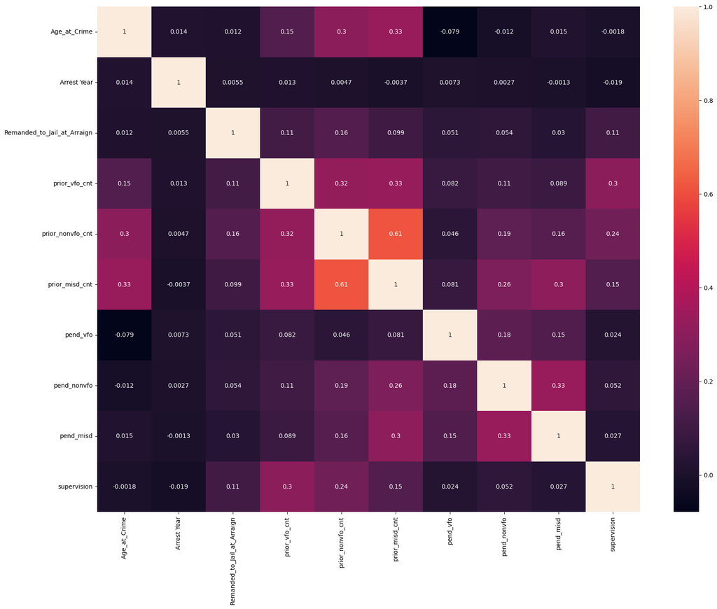

```python
table1['Remanded_to_Jail_at_Arraign']=table1['Remanded_to_Jail_at_Arraign'].astype('category').cat.codes
corrmat = table1.corr()
plt.figure(figsize=(20,15))
g = sns.heatmap(corrmat, annot=True)
```

#### Feature Importance

```python
import matplotlib.pyplot as plt
import numpy as np
from sklearn.ensemble import ExtraTreesClassifier
from sklearn.metrics import accuracy_score


# Fit the first ExtraTreesClassifier model
model = ExtraTreesClassifier(n_estimators=25)
model.fit(X_train, y_train)

# Access the feature importances
importances = model.feature_importances_

# Create a dictionary mapping feature names to their importances
feature_importances = dict(zip(X_train.columns, importances))

# Sort the dictionary by importance values in descending order
sorted_feature_importances = sorted(feature_importances.items(), key=lambda x: x[1], reverse=True)

# Print the feature names and their corresponding importances
for feature_name, importance in sorted_feature_importances:
    print(f"Feature: {feature_name}, Importance: {importance}")
```

```
Feature: Age_at_Crime, Importance: 0.07933815348031749
Feature: prior_nonvfo_cnt, Importance: 0.07456069384012774
Feature: prior_misd_cnt, Importance: 0.05207825866058555
Feature: prior_vfo_cnt, Importance: 0.034267093824472024
Feature: Region_ONYC, Importance: 0.021685311317498058
Feature: Top_Charge_at_Arrest_Violent_Felony_Ind_Y, Importance: 0.02127401281797257
Feature: pend_misd, Importance: 0.020941870957197732
Feature: Top_Charge_Weight_at_Arrest_BF, Importance: 0.02077917319864138
Feature: Arrest Year, Importance: 0.019685806500596446
Feature: Top_Charge_Weight_at_Arrest_DF, Importance: 0.019578048410786766
Feature: Top_Charge_Weight_at_Arrest_CF, Importance: 0.019128740282428055
Feature: pend_nonvfo, Importance: 0.018191466808189793
Feature: supervision, Importance: 0.016726622540472816
Feature: Top_Severity_at_Arraign_Felony, Importance: 0.015872708873679656
Feature: Ethnicity_Non Hispanic, Importance: 0.015066305867207924
Feature: pend_vfo, Importance: 0.014713658211412023
Feature: Top_Severity_at_Arraign_Misdemeanor, Importance: 0.014656192953044095
Feature: Court_Type_Superior, Importance: 0.014597912162882355
Feature: Race_Black, Importance: 0.014465713282795159
Feature: Race_White, Importance: 0.013318268232470419
Feature: Top_Charge_Severity_at_Arrest_Misdemeanor, Importance: 0.012416150596994514
Feature: District_District 3, Importance: 0.012182515740497422
Feature: Gender_Male, Importance: 0.011954727416266256
Feature: Case_Type_Indictment, Importance: 0.011556317115545278
Feature: Top_Charge_Weight_at_Arrest_EF, Importance: 0.010372564708807507
Feature: County_Name_Broome, Importance: 0.009947517658246731
Feature: Arrest_Type_DAT, Importance: 0.008835980341336539
Feature: Top_Charge_Weight_at_Arrest_AM, Importance: 0.0085808425728757
Feature: District_District 5, Importance: 0.008539561224356507
Feature: Ethnicity_Unknown, Importance: 0.007530831617126579
Feature: Case_Type_Superior Court Information, Importance: 0.007454626248194583
Feature: Arrest_Month_May, Importance: 0.00736234720798581
Feature: County_Name_Suffolk, Importance: 0.007347801669435914
Feature: Arrest_Month_Sep, Importance: 0.007284054285423369
Feature: Arrest_Month_Oct, Importance: 0.007269980023674651
Feature: Arrest_Month_Mar, Importance: 0.007243980938617636
Feature: County_Name_Erie, Importance: 0.007197545831540445
Feature: Arrest_Month_Nov, Importance: 0.006946222463646684
Feature: Arrest_Month_Jul, Importance: 0.006880977028513836
Feature: Arrest_Month_Feb, Importance: 0.006839049232305315
```

[output cut: 202 more lines]

```
Feature: Top_Arraign_Law_NAV, Importance: 0.0
Feature: Top_Arraign_Law_NAV-, Importance: 0.0
Feature: Top_Arraign_Law_NC-AC, Importance: 0.0
Feature: Top_Arraign_Law_NC-FPO, Importance: 0.0
Feature: Top_Arraign_Law_NC-LL, Importance: 0.0
Feature: Top_Arraign_Law_NC-ORD, Importance: 0.0
Feature: Top_Arraign_Law_NYS-FC, Importance: 0.0
Feature: Top_Arraign_Law_NYS-PMC, Importance: 0.0
Feature: Top_Arraign_Law_NYS-UFBC, Importance: 0.0
Feature: Top_Arraign_Law_PHLLOC, Importance: 0.0
Feature: Top_Arraign_Law_PL-, Importance: 0.0
Feature: Top_Arraign_Law_PRR, Importance: 0.0
Feature: Top_Arraign_Law_TNH, Importance: 0.0
Feature: Top_Arraign_Law_TOB, Importance: 0.0
Feature: Top_Arraign_Law_TOH, Importance: 0.0
```

```python
table_enc.columns
```

```
Index(['Gender', 'Race', 'Ethnicity', 'Age_at_Crime', 'County_Name',
       'District', 'Region', 'Court_Type', 'Arrest_Month', 'Arrest Year',
       'Arrest_Type', 'Top_Arrest_Law', 'Top_Arrest_Attempt_Indicator',
       'Top_Charge_Severity_at_Arrest', 'Top_Charge_Weight_at_Arrest',
       'Top_Charge_at_Arrest_Violent_Felony_Ind', 'Case_Type',
       'First_Arraign_Date', 'Top_Arraign_Law', 'Top_Severity_at_Arraign',
       'prior_vfo_cnt', 'prior_nonvfo_cnt', 'prior_misd_cnt', 'pend_vfo',
       'pend_nonvfo', 'pend_misd', 'supervision'],
      dtype='object')
```

```python
# select features!

# top charge at arraignment, top charge at arrest, region, ethnicity, race, age_at_arrest, gender,
# priors, arraignment date,
# district
table_enc1 = table_enc[['Gender', 'Race', 'Ethnicity', 'Age_at_Crime', 'Region',
                     'Court_Type','Arrest_Type',"District",
                     'Top_Charge_Severity_at_Arrest', 'Top_Charge_Weight_at_Arrest',
                     'Top_Charge_at_Arrest_Violent_Felony_Ind', 'Case_Type',
                     'First_Arraign_Date', 'Top_Severity_at_Arraign', 'prior_vfo_cnt',
                     'prior_nonvfo_cnt', 'prior_misd_cnt', 'pend_vfo', 'pend_nonvfo',
                     'pend_misd', 'supervision']]
table_str1 = list(table_enc1.select_dtypes(include=['object']).columns)
table_n1 = pd.get_dummies(table_enc1, columns=table_str1,drop_first = True).dropna()
```

```python
scaler = StandardScaler()
X = pd.DataFrame(scaler.fit_transform(table_n1.values), columns=table_n1.columns, index=table_n1.index)
```

```python
X_train, X_test, y_train, y_test = train_test_split(X, y,
                                                    train_size=0.80, test_size=0.20)
```

```python
X_train, X_validate, y_train, y_validate = train_test_split(X_train, y_train,
                                                    train_size=0.75, test_size=0.25)
```

### B. Pick three interesting features you selected using computational techniques. Why does it make sense to use each of them as predictors?

"Region": (string NYC; ONYC = Outside NYC Region the case was filed in) This feature represents the region where the case was filed, with "NYC" indicating cases filed within New York City and "ONYC" indicating cases filed outside of New York City. The region where the case is filed could potentially be a relevant factor in predicting the likelihood of being remanded to jail at arraignment, as different regions may have different judicial practices or policies regarding bail and pretrial detention.

"prior_misd_cnt": (Count of prior convictions for misdemeanor offenses.) This feature represents the count of prior convictions for misdemeanor offenses. While misdemeanors are generally less serious offenses compared to felonies, a higher value of "prior_misd_cnt" may still suggest a higher likelihood of being remanded to jail at arraignment, as a history of prior convictions, regardless of the offense type, could impact the judge's decision.

"prior_vfo_cnt": (contains the counts of prior convictions for violent felonies (including Class A-1 felony offenses along with those offenses defined in Penal Law 70.02) This feature represents the count of prior convictions for violent felonies. A higher value of "prior_vfo_cnt" may indicate a higher likelihood of being remanded to jail at arraignment, as prior convictions for violent felonies could be considered a significant factor in the judge's decision to remand a defendant to jail.

## IV. Prediction

### A. Simulate the performance of a baseline model that predicts that judges will release every defendant. Report the percent accuracy and normalized confusion matrix.

The baseline model for this problem set would be a naive estimate if everything is 0, so an array where everyone is released. This is a simple model acts as a reference in a machine learning project. Its main function is to contextualize the results of trained models. Baseline models usually lack complexity and may have little predictive power.

```python
# Actual y:
y
```

```
2         0
3         0
4         0
5         0
6         0
         ..
582952    0
582953    0
582959    1
582962    0
582965    0
Name: Y, Length: 441115, dtype: uint8
```

```python
# y values if everything was no, or all 0s.
y_pred = np.zeros(len(y))
len(y)
```

```
441115
```

```python
# using the naive model, how correct would the model be?
from sklearn.metrics import confusion_matrix
from sklearn.metrics import accuracy_score, precision_score, recall_score, f1_score,confusion_matrix
match_array = y_pred == y
percent_match = np.mean(match_array) * 100


# Evaluate the performance of the baseline model
accuracy = accuracy_score(y, y_pred)
precision = precision_score(y, y_pred)
recall = recall_score(y, y_pred)
f1 = f1_score(y, y_pred)

# Print the evaluation metrics
print("Accuracy: {:.2f}".format(accuracy))
print("Precision: {:.2f}".format(precision))
print("Recall: {:.2f}".format(recall))
print("F1-score: {:.2f}".format(f1))

print("Percent match: {:.2f}%".format(percent_match))


print("Normalized Confusion Matrix:")
conf_mat = confusion_matrix(y_pred, y, normalize='true')
print(conf_mat)
```

```
Accuracy: 0.97
Precision: 0.00
Recall: 0.00
F1-score: 0.00
Percent match: 96.69%
Normalized Confusion Matrix:
[[0.96692926 0.03307074]
 [0.         0.        ]]
```

96.69% will be the baseline with which we will base the accuracy of our models and predictions and predictions. This classifier serves as a simple baseline to compare against other more complex classifiers.

**Accuracy: 0.97**

The Accuracy of 0.97 indicates that the model correctly classified 97% of the samples.

**Precision: 0.00**

**Recall: 0.00**

The Recall of 0.00 indicates that the model did not identify any of the true positive samples out of the total actual positive samples. This suggests that the model has a very high rate of false negatives, i.e., it is failing to identify many positive samples.

**F1-score: 0.00**

The F1-score of 0.00 is the harmonic mean of Precision and Recall, and it is also very low in this case, which suggests that the model is not performing well overall.

**Normalized Confusion Matrix Interpretation**

The Normalized Confusion Matrix shows the proportion of true positive, false positive, true negative, and false negative samples for each class. The matrix shows that the model correctly classified 96.69% of the samples, but it incorrectly classified 3.31% of the samples as well. In this case, the model has correctly classified most of the negative samples, but it is struggling to identify positive samples, resulting in a high number of false negatives.

#### Logistic Regression

```python
# use y as an array as everything 0 to represent everyone being released; ake the percentage between actual
# release vs naive all 0s percentage. naive model is everything is 0.
```

```python
import pandas as pd
from sklearn.linear_model import LogisticRegression
from sklearn.model_selection import train_test_split
from sklearn.metrics import accuracy_score, precision_score, recall_score, f1_score,confusion_matrix

model = LogisticRegression()
model.fit(X_train, y_train)

# Predict on the testing set
y_pred = model.predict(X_test)

cm = confusion_matrix(y_test, y_pred)

# Normalize the confusion matrix
cm_norm = cm.astype('float') / cm.sum(axis=1)[:, np.newaxis]

# Evaluate the performance of the baseline model
accuracy = accuracy_score(y_test, y_pred)
precision = precision_score(y_test, y_pred)
recall = recall_score(y_test, y_pred)
f1 = f1_score(y_test, y_pred)

# Print the evaluation metrics
print("Accuracy: {:.2f}".format(accuracy))
print("Precision: {:.2f}".format(precision))
print("Recall: {:.2f}".format(recall))
print("F1-score: {:.2f}".format(f1))

# Print the normalized confusion matrix
print("Normalized Confusion Matrix:")
print(cm_norm)
```

```
Accuracy: 0.97
Precision: 0.69
Recall: 0.22
F1-score: 0.33
Normalized Confusion Matrix:
[[0.99669491 0.00330509]
 [0.7837931  0.2162069 ]]
```

**Accuracy: 0.97**

Accuracy is the ratio of correctly predicted instances to the total number of instances in the testing set. In this case, an accuracy of 0.97 means that the model correctly predicted the class labels for approximately 97% of the instances in the testing set.

As such, although the accuracy of the model is high at 0.97, the precision, recall, and F1-score are relatively low. This suggests that the model's overall accuracy is driven by a high number of true negatives, but it may struggle with correctly predicting positive instances, as evidenced by the low precision, recall, and F1-score.

**Normalized Confusion Matrix Interpretation**

- Higher values on the diagonal (top-left to bottom-right) indicate higher accuracy or correctness of predictions.
- Lower values off the diagonal (top-right and bottom-left) indicate misclassifications or errors made by the model.
- The sum of values in each row of the normalized confusion matrix should be close to 1, as it represents the proportion of instances for each true class.
- The normalized confusion matrix provides insights into the performance of the model in terms of correctly predicting instances for each class, and can be used to assess the model's accuracy, precision, recall, and F1-score for each class.

### B. Choose three different prediction techniques that are appropriate to the problem at hand. Describe the basic mechanism of each, benefits and drawbacks, and any other criteria you factored into your decision. Why is each a reasonable choice for this context?

#### Random Forest Classifier

- **Basic Mechanism:** Random Forest Classifier is an ensemble learning technique that combines multiple decision trees to make predictions. Each tree in the forest is trained on a random subset of features and a random subset of data points, which introduces randomness and diversity into the model. The final prediction is obtained by averaging or taking a majority vote of the predictions from individual trees.
- **Benefits:** Random Forest Classifier can handle a wide range of data types, including categorical and numerical features, and can capture complex nonlinear relationships and interactions among features. It is less prone to overfitting compared to single decision trees, as the averaging or majority voting of predictions from multiple trees helps to reduce variance and improve model generalization ability. In this case, this model is ideal for the binary classifiers that we use to predict whether or not someone is Remanded at Arraign.
- **Drawbacks:** Random Forest Classifier may require careful tuning of hyperparameters such as the number of trees, maximum depth of each tree, and the number of features to consider at each split. The model may also become less interpretable compared to single decision trees, as the predictions are obtained from an ensemble of trees.
- **Other Criteria:** Random Forest Classifier is a good choice when you want to build a robust and accurate model that can handle complex patterns in the data. It is suitable for both classification and regression tasks and can be considered when interpretability is not a primary concern. It is well-suited for binary prediction classification tasks due to its ability to handle complex interactions among features and capture non-linear relationships in the data. The randomness introduced during tree construction helps to reduce overfitting, making it more robust and reliable for binary prediction tasks. Additionally, Random Forest Classifier can handle high-dimensional datasets with a large number of features, making it suitable for binary classification tasks that involve a large number of predictors.

#### Ridge Classifier

- **Basic Mechanism:** Ridge Classifier is a linear classifier that uses L2 regularization to shrink the magnitude of the coefficients in the model. It minimizes the sum of squared errors between the predicted and actual values, subject to a constraint that limits the size of the coefficients. This constraint reduces the variance of the model and prevents overfitting by penalizing large coefficients.
- **Benefits:** Ridge Classifier can handle high-dimensional datasets with a large number of features, as it is able to select a subset of informative features and shrink the coefficients of less important features towards zero. It is less prone to overfitting compared to ordinary least squares regression, which can be useful when dealing with noisy or sparse data. Ridge Classifier is also computationally efficient and can be used with both binary and multi-class classification problems.
- **Drawbacks:** Ridge Classifier assumes that the relationship between the predictors and the target variable is linear and may not perform well when there are non-linear relationships or interactions among features. It also requires tuning of the regularization parameter to balance bias and variance in the model, which can be a challenge. Additionally, Ridge Classifier may not perform well when there are irrelevant features in the data, as the regularization penalty may not be able to eliminate them completely.
- **Other Criteria:** Ridge Classifier is a reasonable choice for the context of predicting Remanded_to_Jail_at_Arraign, a binary categorical variable of Yes or No. This is because the dataset may have many features, and Ridge Classifier is able to handle high-dimensional data efficiently. Additionally, the regularization term in Ridge Classifier can help to prevent overfitting and improve the generalization ability of the model. Since the relationship between the predictor variables and the response variable may not be known in advance, a linear classifier such as Ridge Classifier may be a good starting point to explore the data and identify the most important features. Ridge Classifier is also computationally efficient and can handle both binary and multi-class classification problems, making it a versatile choice for classification tasks.

#### Extra Trees Classifier

- **Basic Mechanism:** Extra Trees Classifier is an ensemble learning technique that combines multiple decision trees to make predictions. However, unlike traditional decision trees, Extra Trees Classifier introduces additional randomness by selecting random subsets of features and splitting points during the tree construction process. This results in a more diverse set of trees and can improve the model's generalization ability.
- **Benefits:** Extra Trees Classifier can handle a large number of features and is less prone to overfitting compared to traditional decision trees, as the randomness introduced during tree construction reduces the risk of trees memorizing the training data. It can also capture complex nonlinear relationships and interactions among features, making it suitable for datasets with complex patterns.
- **Drawbacks:** Extra Trees Classifier may require careful tuning of hyperparameters such as the number of trees and the maximum depth of each tree to achieve optimal performance. The randomness introduced during tree construction may also make the model less interpretable compared to single decision trees.
- **Other Criteria:** Extra Trees Classifier is a good choice when you have a large dataset with complex patterns and you want to reduce the risk of overfitting. It can also be considered when interpretability is not a priority, and you are looking for an ensemble method that can capture complex nonlinear relationships. This makes it ideal for binary prediction classification tasks where complex patterns and interactions among features need to be captured. The randomness introduced during tree construction helps to reduce overfitting, making it more reliable for binary classification tasks. Additionally, Extra Trees Classifier can handle large datasets with high-dimensional features, making it suitable for binary classification tasks that involve a large number of predictors.

### C. Train your three models. Report the percent accuracy and normalized confusion matrix for each model. Which model do you end up selecting to make your prediction and why?

#### Random Forest Model

```python
import pandas as pd
from sklearn.ensemble import RandomForestClassifier
from sklearn.model_selection import train_test_split
from sklearn.metrics import accuracy_score, precision_score, recall_score, f1_score, confusion_matrix

# Create and fit the Random Forest model
rf = RandomForestClassifier(n_estimators=100, random_state=42)
rf.fit(X_train, y_train)

# Use the model to make predictions
y_pred = rf.predict(X_test)

# Calculate evaluation metrics
accuracy = accuracy_score(y_test, y_pred)
precision = precision_score(y_test, y_pred)
recall = recall_score(y_test, y_pred)
f1 = f1_score(y_test, y_pred)

# Print the evaluation metrics
print("Accuracy: {:.2f}".format(accuracy))
print("Precision: {:.2f}".format(precision))
print("Recall: {:.2f}".format(recall))
print("F1-score: {:.2f}".format(f1))


cm = confusion_matrix(y_test, y_pred)

# Normalize the confusion matrix
cm_norm = cm.astype('float') / cm.sum(axis=1)[:, np.newaxis]

# Print the normalized confusion matrix
print("Normalized Confusion Matrix:")
print(cm_norm)
```

```
Accuracy: 0.98
Precision: 0.79
Recall: 0.37
F1-score: 0.50
Normalized Confusion Matrix:
[[0.99661287 0.00338713]
 [0.63       0.37      ]]
```

#### Ridge Classifier

```python
import pandas as pd
from sklearn.linear_model import RidgeClassifier
from sklearn.model_selection import train_test_split
from sklearn.metrics import accuracy_score, precision_score, recall_score, f1_score, confusion_matrix

# Create and fit the KNN model
ridge_class = RidgeClassifier()
ridge_class.fit(X_train, y_train)

# Use the model to make predictions
y_pred = ridge_class.predict(X_test)

# Calculate evaluation metrics
accuracy = accuracy_score(y_test, y_pred)
precision = precision_score(y_test, y_pred)
recall = recall_score(y_test, y_pred)
f1 = f1_score(y_test, y_pred)

# Print the evaluation metrics
print("Accuracy: {:.2f}".format(accuracy))
print("Precision: {:.2f}".format(precision))
print("Recall: {:.2f}".format(recall))
print("F1-score: {:.2f}".format(f1))

cm = confusion_matrix(y_test, y_pred)

# Normalize the confusion matrix
cm_norm = cm.astype('float') / cm.sum(axis=1)[:, np.newaxis]

# Print the normalized confusion matrix
print("Normalized Confusion Matrix:")
print(cm_norm)
```

```
Accuracy: 0.97
Precision: 0.70
Recall: 0.05
F1-score: 0.10
Normalized Confusion Matrix:
[[9.99226469e-01 7.73531170e-04]
 [9.46896552e-01 5.31034483e-02]]
```

#### Extra-Trees Classifier

```python
import pandas as pd
from sklearn.ensemble import ExtraTreesClassifier
from sklearn.model_selection import train_test_split
from sklearn.metrics import accuracy_score, precision_score, recall_score, f1_score, confusion_matrix

extra_trees = ExtraTreesClassifier(n_estimators=100, random_state=42)
extra_trees.fit(X_train, y_train)

# Use the model to make predictions
y_pred = extra_trees.predict(X_test)

# Calculate evaluation metrics
accuracy = accuracy_score(y_test, y_pred)
precision = precision_score(y_test, y_pred)
recall = recall_score(y_test, y_pred)
f1 = f1_score(y_test, y_pred)

# Print the evaluation metrics
print("Accuracy: {:.2f}".format(accuracy))
print("Precision: {:.2f}".format(precision))
print("Recall: {:.2f}".format(recall))
print("F1-score: {:.2f}".format(f1))

cm = confusion_matrix(y_test, y_pred)

# Normalize the confusion matrix
cm_norm = cm.astype('float') / cm.sum(axis=1)[:, np.newaxis]

# Print the normalized confusion matrix
print("Normalized Confusion Matrix:")
print(cm_norm)
```

```
Accuracy: 0.98
Precision: 0.72
Recall: 0.40
F1-score: 0.52
Normalized Confusion Matrix:
[[0.99474936 0.00525064]
 [0.59655172 0.40344828]]
```

As such, the **Random Forest Classifier** appears to be the most suitable classifier for predicting whether someone will be remanded to jail at arraignment, based on its high accuracy, precision, and relatively balanced F1-score. The classifier's ability to handle complex interactions among features and capture non-linear relationships in the data makes it a reasonable choice for this binary prediction classification task.

### D. Tune your model selection to improve performance. What hyperparameters do you end up using? List the percent accuracy and normalized confusion matrix of your final model.

```python
from sklearn.model_selection import RandomizedSearchCV
import numpy as np
import pandas as pd

n_estimators =  [10, 20, 30, 40, 50]
max_features = ['sqrt', 'log2', None]
max_depth = [int(x) for x in np.linspace(10, 120, num = 12)]
min_samples_split = [2, 4, 6, 8, 10]
min_samples_leaf = [1, 3, 4]
bootstrap = [True, False]

random_grid = {'n_estimators': n_estimators,
               'max_features': max_features,
               'max_depth': max_depth,
               'min_samples_split': min_samples_split,
               'min_samples_leaf': min_samples_leaf,
               'bootstrap': bootstrap}

# select a random sample of 30% of the total data
sample_size = int(0.25 * X_train.shape[0])
X_train_sample = X_train.sample(sample_size)
y_train_sample = y_train[X_train_sample.index]

rf_random = RandomizedSearchCV(estimator=rf, param_distributions=random_grid, n_iter=50, cv=5, verbose=2, random_state=35, n_jobs=-1)
rf_random.fit(X_train_sample, y_train_sample)

# this prints the contents of the parameters in the random grid
print('Random grid: ', random_grid, '\n')

# print the best parameters
vals = rf_random.best_params_
print('Best Parameters from Random Search: ', vals, '\n')
```

```
Fitting 5 folds for each of 50 candidates, totalling 250 fits
Random grid:  {'n_estimators': [10, 20, 30, 40, 50], 'max_features': ['sqrt', 'log2', None], 'max_depth': [10, 20, 30, 40, 50, 60, 70, 80, 90, 100, 110, 120], 'min_samples_split': [2, 4, 6, 8, 10], 'min_samples_leaf': [1, 3, 4], 'bootstrap': [True, False]}

Best Parameters from Random Search:  {'n_estimators': 50, 'min_samples_split': 8, 'min_samples_leaf': 3, 'max_features': None, 'max_depth': 60, 'bootstrap': True}
```

```python
print (f'Train Accuracy for RandomizedSearchCV : {rf_random.score(X_train,y_train):.3f}')
print (f'Test Accuracy for RandomizedSearchCV : {rf_random.score(X_test,y_test):.3f}')
```

```
Train Accuracy for RandomizedSearchCV : 0.978
Test Accuracy for RandomizedSearchCV : 0.976
```

```python
rf1=RandomForestClassifier(random_state=42, max_features=vals["max_features"],
                           n_estimators= vals["n_estimators"],min_samples_split= vals["min_samples_split"],
                           max_depth=vals["max_depth"],
                           bootstrap = vals["bootstrap"],min_samples_leaf = vals["min_samples_leaf"],
                           criterion='gini')
rf1.fit(X_train, y_train)

# Use the model to make predictions
y_pred = rf1.predict(X_test)

# Calculate evaluation metrics
accuracy = accuracy_score(y_test, y_pred)
precision = precision_score(y_test, y_pred)
recall = recall_score(y_test, y_pred)
f1 = f1_score(y_test, y_pred)

# Print the evaluation metrics
print("Accuracy: {:.2f}".format(accuracy))
print("Precision: {:.2f}".format(precision))
print("Recall: {:.2f}".format(recall))
print("F1-score: {:.2f}".format(f1))


cm = confusion_matrix(y_test, y_pred)

# Normalize the confusion matrix
cm_norm = cm.astype('float') / cm.sum(axis=1)[:, np.newaxis]

# Print the normalized confusion matrix
print("Normalized Confusion Matrix:")
print(cm_norm)
```

```
Accuracy: 0.98
Precision: 0.76
Recall: 0.45
F1-score: 0.56
Normalized Confusion Matrix:
[[0.99519473 0.00480527]
 [0.55275862 0.44724138]]
```

When comparing the two sets of results of tuning the random forest classifer and not tuning the random forest classifier, we get these results:

**Tuned:** Accuracy: 0.98

Precision: 0.76

Recall: 0.45

F1-score: 0.56

Normalized Confusion Matrix:

[[0.99519473 0.00480527] [0.55275862 0.44724138]]

**Untuned:** Accuracy: 0.98

Precision: 0.79

Recall: 0.37

F1-score: 0.50

Normalized Confusion Matrix: [[0.99661287 0.00338713] [0.63 0.37 ]]

It appears that the tuned model has a higher recall score, while the untuned model has a higher precision score. This means that the tuned model is better at identifying the positive class (people who are remanded to jail), but at the cost of more false positives. On the other hand, the untuned model is better at avoiding false positives, but at the cost of missing more true positives. If the goal of our model is to identify as many people who should be remanded to jail as possible, even if it means some false positives, then the tuned model with higher recall is likely the better choice. However, if the goal is to minimize false positives and ensure that only those who truly need to be remanded to jail are, then the untuned model with higher precision may be the better choice. It is important to note that both models have a high accuracy score, so both are performing well overall.

### E. Is it reasonable to perform cross-validation with this model? Why or why not?

Theoretically, cross-validation could be done on this dataset, but it would be too computationally heavy to do so due to the fact that we have so many rows and features selected. Running cross validation took me about 30 minutes to perform on my dataset.

## V. Interpretability

### A. Create a dataframe that can be used to analyze your model’s performance, especially relative to judges. This should contain (1) all the features the model was trained on, (2) the judge’s arraignment release decision, (3) the probability score of the data point computed by the model, and (4) the model’s ultimate prediction.

#### Note: #3 can be done using the predict_proba method in scikit-learn. It functions similarly to predict but returns a numeric score rather than a class

```python
predict_probas = rf1.predict_proba(X)
predict = rf1.predict(X)
predict_probas = predict_probas[:,1]
X_n = table_enc.copy()
X_n["Predict_prob"] = predict_probas.tolist()
X_n["Model_pred"] = predict.tolist()
X_n['Judge_Decision'] = y
```

```python
X_n
```

|  | Gender | Race | Ethnicity | Age_at_Crime | County_Name | District | Region | Court_Type | Arrest_Month | Arrest Year | ... | prior_vfo_cnt | prior_nonvfo_cnt | prior_misd_cnt | pend_vfo | pend_nonvfo | pend_misd | supervision | Predict_prob | Model_pred | Judge_Decision |
| --- | --- | --- | --- | --- | --- | --- | --- | --- | --- | --- | --- | --- | --- | --- | --- | --- | --- | --- | --- | --- | --- |
| 2 | Female | White | Hispanic | 22 | Westchester | District 9 | ONYC | Local | Jul | 2020.0 | ... | 0.0 | 0.0 | 0.0 | 0.0 | 1.0 | 0.0 | 0.0 | 0.008000 | 0 | 0 |
| 3 | Female | Unknown | Unknown | 33 | Chautauqua | District 8 | ONYC | Local | Mar | 2021.0 | ... | 0.0 | 0.0 | 0.0 | 0.0 | 0.0 | 0.0 | 0.0 | 0.000000 | 0 | 0 |
| 4 | Male | Black | Non Hispanic | 49 | Suffolk | District 10S | ONYC | Local | Feb | 2021.0 | ... | 0.0 | 3.0 | 10.0 | 0.0 | 1.0 | 0.0 | 0.0 | 0.000000 | 0 | 0 |
| 5 | Male | Black | Non Hispanic | 24 | Kings | District 2 | NYC | Superior | May | 2021.0 | ... | 0.0 | 0.0 | 0.0 | 0.0 | 0.0 | 0.0 | 0.0 | 0.023405 | 0 | 0 |
| 6 | Male | Black | Non Hispanic | 23 | Kings | District 2 | NYC | Local | Feb | 2022.0 | ... | 0.0 | 0.0 | 0.0 | 0.0 | 0.0 | 0.0 | 0.0 | 0.000000 | 0 | 0 |
| ... | ... | ... | ... | ... | ... | ... | ... | ... | ... | ... | ... | ... | ... | ... | ... | ... | ... | ... | ... | ... | ... |
| 582952 | Male | Black | Non Hispanic | 56 | New York | District 1 | NYC | Local | Jun | 2021.0 | ... | 1.0 | 4.0 | 10.0 | 0.0 | 0.0 | 1.0 | 0.0 | 0.055762 | 0 | 0 |
| 582953 | Female | White | Hispanic | 25 | Westchester | District 9 | ONYC | Local | Jan | 2021.0 | ... | 0.0 | 0.0 | 0.0 | 0.0 | 0.0 | 0.0 | 0.0 | 0.000000 | 0 | 0 |
| 582959 | Male | Black | Hispanic | 21 | Erie | District 8 | ONYC | Local | Jan | 2022.0 | ... | 0.0 | 1.0 | 0.0 | 0.0 | 0.0 | 1.0 | 1.0 | 0.326481 | 0 | 1 |
| 582962 | Male | White | Hispanic | 20 | Kings | District 2 | NYC | Local | Feb | 2021.0 | ... | 0.0 | 0.0 | 0.0 | 0.0 | 0.0 | 0.0 | 0.0 | 0.000000 | 0 | 0 |
| 582965 | Male | White | Non Hispanic | 43 | Bronx | District 12 | NYC | Local | Feb | 2021.0 | ... | 0.0 | 2.0 | 10.0 | 0.0 | 0.0 | 0.0 | 0.0 | 0.000000 | 0 | 0 |

441115 rows × 30 columns

```python
X_n.columns
```

```
Index(['Gender', 'Race', 'Ethnicity', 'Age_at_Crime', 'County_Name',
       'District', 'Region', 'Court_Type', 'Arrest_Month', 'Arrest Year',
       'Arrest_Type', 'Top_Arrest_Law', 'Top_Arrest_Attempt_Indicator',
       'Top_Charge_Severity_at_Arrest', 'Top_Charge_Weight_at_Arrest',
       'Top_Charge_at_Arrest_Violent_Felony_Ind', 'Case_Type',
       'First_Arraign_Date', 'Top_Arraign_Law', 'Top_Severity_at_Arraign',
       'prior_vfo_cnt', 'prior_nonvfo_cnt', 'prior_misd_cnt', 'pend_vfo',
       'pend_nonvfo', 'pend_misd', 'supervision', 'Predict_prob', 'Model_pred',
       'Judge_Decision'],
      dtype='object')
```

```python
X_n.dtypes
```

```
Gender                                      object
Race                                        object
Ethnicity                                   object
Age_at_Crime                                 int64
County_Name                                 object
District                                    object
Region                                      object
Court_Type                                  object
Arrest_Month                                object
Arrest Year                                float64
Arrest_Type                                 object
Top_Arrest_Law                              object
Top_Arrest_Attempt_Indicator                object
Top_Charge_Severity_at_Arrest               object
Top_Charge_Weight_at_Arrest                 object
Top_Charge_at_Arrest_Violent_Felony_Ind     object
Case_Type                                   object
First_Arraign_Date                          object
Top_Arraign_Law                             object
Top_Severity_at_Arraign                     object
prior_vfo_cnt                              float64
prior_nonvfo_cnt                           float64
prior_misd_cnt                             float64
pend_vfo                                   float64
pend_nonvfo                                float64
pend_misd                                  float64
supervision                                float64
Predict_prob                               float64
Model_pred                                   int64
Judge_Decision                               uint8
dtype: object
```

### B. Summary Statistics: Compute the average judge decision, model probability score, and model prediction for 1) all cases, 2) cases with black defendants, 3) cases with non-black defendants, 4) cases with male defendants, 5) cases with non-male defendants, 6) cases with defendants at or above the median age, and 7) cases with defendants below the median age. What do you observe about race, gender, and age differences for these scores? Include several visualizations to help your audience understand the group differences.

```python
import pandas as pd

# Compute summary statistics for all cases
summary_all = X_n[["Model_pred", "Predict_prob","Judge_Decision"]].mean()

# Compute summary statistics for cases with black defendants
summary_black = X_n[X_n["Race"]=="Black"][["Model_pred", "Predict_prob","Judge_Decision"]].mean()

# Compute summary statistics for cases with non-black defendants
summary_nonblack = X_n[X_n["Race"]!="Black"][["Model_pred", "Predict_prob","Judge_Decision"]].mean()

# Compute summary statistics for cases with male defendants
summary_male = X_n[X_n["Gender"]=="Male"][["Model_pred", "Predict_prob","Judge_Decision"]].mean()

# Compute summary statistics for cases with non-male defendants
summary_nonmale = X_n[X_n["Gender"]!="Male"][["Model_pred", "Predict_prob","Judge_Decision"]].mean()

# Compute summary statistics for cases with defendants at or above the median age
median_age = X_n["Age_at_Crime"].median()
summary_above_median_age = X_n[X_n["Age_at_Crime"]>=median_age][["Model_pred", "Predict_prob","Judge_Decision"]].mean()

# Compute summary statistics for cases with defendants below the median age
summary_below_median_age = X_n[X_n["Age_at_Crime"]<median_age][["Model_pred", "Predict_prob","Judge_Decision"]].mean()

# Create a dataframe with the summary statistics
df_summary = pd.DataFrame({
    "Group": ["All", "Black", "Non-Black", "Male", "Non-Male", "Above Median Age", "Below Median Age"],
    "Mean Judge Decision": [summary_all[2], summary_black[2], summary_nonblack[2], summary_male[2], summary_nonmale[2], summary_above_median_age[2], summary_below_median_age[2]],
    "Mean Model Probability Score": [summary_all[1], summary_black[1], summary_nonblack[1], summary_male[1], summary_nonmale[1], summary_above_median_age[1], summary_below_median_age[1]],
    "Mean Model Prediction": [summary_all[0], summary_black[0], summary_nonblack[0], summary_male[0], summary_nonmale[0], summary_above_median_age[0], summary_below_median_age[0]]
})

# Print the dataframe
df_summary
```

|  | Group | Mean Judge Decision | Mean Model Probability Score | Mean Model Prediction |
| --- | --- | --- | --- | --- |
| 0 | All | 0.033071 | 0.033589 | 0.020781 |
| 1 | Black | 0.041743 | 0.041420 | 0.026682 |
| 2 | Non-Black | 0.026195 | 0.027379 | 0.016103 |
| 3 | Male | 0.038185 | 0.037992 | 0.024504 |
| 4 | Non-Male | 0.012222 | 0.015637 | 0.005605 |
| 5 | Above Median Age | 0.037266 | 0.038023 | 0.026908 |
| 6 | Below Median Age | 0.028305 | 0.028550 | 0.013821 |

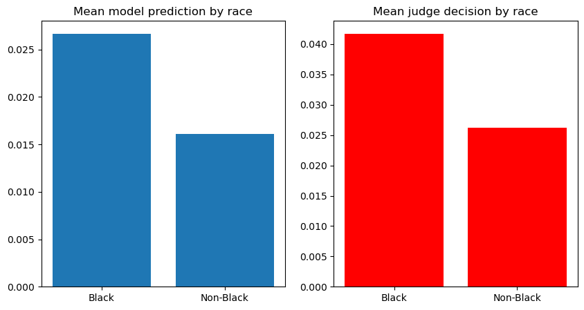

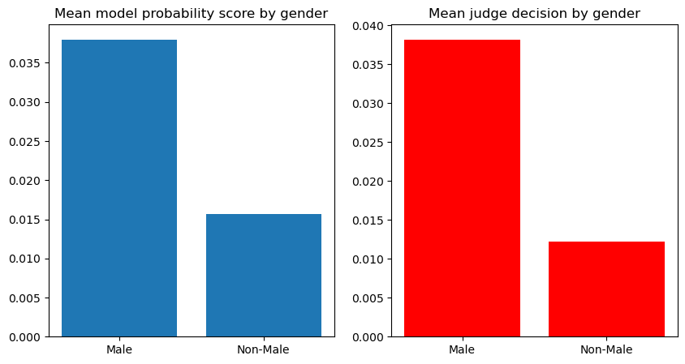

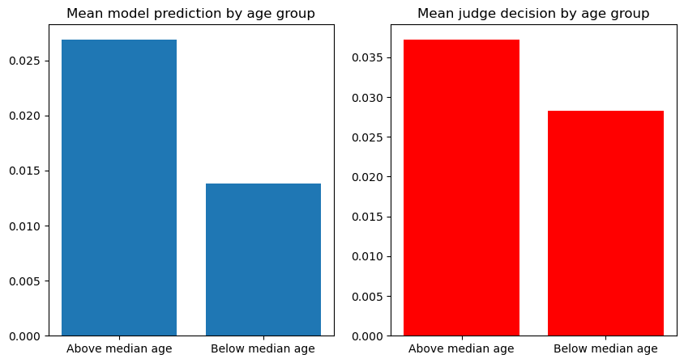

```python
import matplotlib.pyplot as plt

# Set the figure size
fig, axs = plt.subplots(1, 2, figsize=(10, 5))

# Create a bar plot for mean model prediction by race
axs[0].bar(["Black", "Non-Black"], [summary_black["Model_pred"], summary_nonblack["Model_pred"]])
axs[0].set_title("Mean model prediction by race")

axs[1].bar(["Black", "Non-Black"], [summary_black["Judge_Decision"], summary_nonblack["Judge_Decision"]], color = "red")
axs[1].set_title("Mean judge decision by race")

plt.show()

# Create a bar plot for mean model probability score by gender
fig, axs = plt.subplots(1, 2, figsize=(10, 5))

axs[0].bar(["Male", "Non-Male"], [summary_male["Predict_prob"], summary_nonmale["Predict_prob"]])
axs[0].set_title("Mean model probability score by gender")

axs[1].bar(["Male", "Non-Male"], [summary_male["Judge_Decision"], summary_nonmale["Judge_Decision"]], color = "red")
axs[1].set_title("Mean judge decision by gender")

plt.show()

# Create a bar plot for mean model prediction by age group
fig, axs = plt.subplots(1, 2, figsize=(10, 5))

axs[0].bar(["Above median age", "Below median age"], [summary_above_median_age["Model_pred"], summary_below_median_age["Model_pred"]])
axs[0].set_title("Mean model prediction by age group")

axs[1].bar(["Above median age", "Below median age"], [summary_above_median_age["Judge_Decision"], summary_below_median_age["Judge_Decision"]], color = "red")
axs[1].set_title("Mean judge decision by age group")

plt.show()
```

- Mean Judge Decision: This value represents the proportion of individuals in the group who were remanded at arraign, based on the judge's decision.
- Mean Model Probability Score: This value represents the average probability score assigned by the model to the group. The probability score indicates how likely the model thinks an individual in the group is to be remanded at arraign.
- Mean Model Prediction: This value represents the proportion of individuals in the group that the model predicted would be remanded at arraign.

In general, comparing the mean judge decision to the mean model prediction and probability score can help us evaluate the accuracy of the model in predicting the judge's decision. If the mean model prediction and probability score are similar to the mean judge decision, then the model is performing well in predicting the judge's decision. If there is a large difference between the mean model prediction and the mean judge decision, then the model may not be accurate in predicting the judge's decision.

### C. What are three features with significant predictive value in your model? Explain why this might be the case. This can be determined using the coef_ or feature*importances* methods, depending on the model you chose.

The features selected below are from when we one-hot-encoded the categorical variables from the table we used above. The features will be selected based off of the column names afer they've been one-hot-encoded.

```python
importances = rf1.feature_importances_
sorted_idx = np.argsort(importances)[::-1]
print("Top three features:")
for idx in sorted_idx[:3]:
    print("{:d}. feature {} ({:.2f})".format(idx + 1, X.columns[idx], importances[idx]))
```

```
Top three features:
18. feature Region_ONYC (0.12)
1. feature Age_at_Crime (0.11)
3. feature prior_nonvfo_cnt (0.08)
```

## VI. Compare to Judge Decisions

### A. Judges have access to basic risk assessment tools when making detention decisions. For this section, we will interpret the model probability scores as the failure-to-appear risk. What is the average risk score for the riskiest 1% of defendants? What percent of these do judges detain? What is the average risk score for the least risky 1% of defendants? What percent of these do judges detain? Overall, do judge decisions seem to align with the perceived risk of the defendant?

1.) What is the average risk score for the riskiest 1% of defendants? What percent of these do judges detain?

```python
# Sort X_n by Predict_prob in descending order
X_n_sorted = X_n.sort_values(by='Predict_prob', ascending=False)

# Select the top 1% of defendants based on their Predict_prob score
top_1_percent = X_n_sorted.quantile(0.99)['Predict_prob']

# Get the average risk score for the riskiest 1% of defendants
avg_risk_score_riskiest = X_n_sorted[X_n_sorted['Predict_prob'] >= top_1_percent]['Predict_prob'].mean()

print("Average risk score for the riskiest 1% of defendants:", avg_risk_score_riskiest)
```

```
Average risk score for the riskiest 1% of defendants: 0.9206798647924537
```

2.) What percent of these do judges detain?

```python
# Calculate the percentage of the riskiest defendants that judges detain
detention_rate_riskiest = (X_n_sorted[X_n_sorted['Predict_prob'] >= top_1_percent]['Judge_Decision'] == 1).mean() * 100

print("Percentage of riskiest defendants that judges detain:", detention_rate_riskiest, "%")
```

```
Percentage of riskiest defendants that judges detain: 96.16953762466002 %
```

3.) What is the average risk score for the least risky 1% of defendants?

```python
# Select the bottom 1% of defendants based on their Predict_prob score
bottom_1_percent = X_n_sorted.quantile(0.01)['Predict_prob']

# Get the average risk score for the least risky 1% of defendants
avg_risk_score_least_risky = X_n_sorted[X_n_sorted['Predict_prob'] <= bottom_1_percent]['Predict_prob'].mean()

print("Average risk score for the least risky 1% of defendants:", avg_risk_score_least_risky)
```

```
Average risk score for the least risky 1% of defendants: 0.0
```

4.) What percent of these do judges detain?

```python
# Calculate the percentage of the least risky defendants that judges detain
detention_rate_least_risky = (X_n_sorted[X_n_sorted['Predict_prob'] <= bottom_1_percent]['Judge_Decision'] == 1).mean() * 100

print("Percentage of least risky defendants that judges detain:", detention_rate_least_risky, "%")
```

```
Percentage of least risky defendants that judges detain: 0.10162695232744143 %
```